# What Drives a Track’s Popularity on Spotify?

Samantha Mesa

2026-11-12

## Approach

A record label wants to know what makes a track popular: is it the artist, the genre, the era, or the track itself, and does that change over time? To answer this, I will clean and combine 2 Kaggle extracts of the Spotify catalog, explore era and genre patterns with tables and charts, and then fit a random forest with and without the artist’s fame to see what the track, its genre, and its era add on their own. This analysis is fully reproducible: raw data is in data/raw/, all paths are relative, the random seed is fixed, and the session information is printed at the end of the report.

## Challenges

The first problem is that of data quality. The two files store the same fields differently (e.g., duration units, genre formats, partial release dates), one has unescaped quotes, which cause some CSV readers to silently drop rows, and genres are missing for many tracks, with about 40% still blank after combining both files, and belong to the artist rather than the track, forcing a choice between one row per genre (which inflates counts) and broad genre families (which lose detail). The second challenge is interpretation. Spotify’s popularity score rewards recent listening, and artist popularity is tightly coupled to the popularity of the artist’s own tracks (making the model, in part, circular, so I also run it without those variables and split training and test data by artist to avoid overstating accuracy). The data is observational and does not contain audio features like tempo or danceability; therefore, the model will explain little of the variation and will show association, not causation. Finally, I only have five minutes to present, so I will have to pick the few most compelling charts and results, rather than trying to show everything.

## 1. Setup

```r
# Packages required (all on CRAN). Stop early with a clear message if any are missing.
needed  <- c("tidyverse", "data.table", "ranger", "knitr", "scales")
missing <- setdiff(needed, rownames(installed.packages()))
if (length(missing) > 0) {
  stop("Please install: install.packages(c(",
       paste0('"', missing, '"', collapse = ", "), "))")
}

library(tidyverse)   # dplyr, ggplot2, readr, stringr, lubridate, ...
library(ranger)      # fast random forest
library(knitr)       # kable() tables
library(scales)      # label formatting
set.seed(607)        # fixed seed -> identical split, forest, and results every run

# Consistent look for every chart
col_main   <- "#15803D"   # green
col_accent <- "#7E22CE"   # purple
theme_set(theme_minimal(base_size = 12) +
            theme(plot.title = element_text(face = "bold"),
                  panel.grid.minor = element_blank()))

dir.create("data/processed", showWarnings = FALSE, recursive = TRUE)
```

## 2. Load and clean the data

The two files describe the same kind of record but are stored differently:

|  | `spotify_data_clean.csv` | `track_data_final.csv` |
| --- | --- | --- |
| Duration | minutes (`track_duration_min`) | milliseconds (`track_duration_ms`) |
| Genres | plain text, `N/A` when missing | Python-style list, `[]` when missing |
| Release date | always full date | sometimes year only (`2009`) or `0000` |
| Artist stats | whole numbers | decimals, a few blanks |

```r
# NOTE: spotify_data_clean.csv has a few unescaped inch marks inside quoted names
# (e.g., "The 12" Singles"). readr silently loses those rows (8,573 of 8,582), so we
# read both files with data.table::fread(), which keeps every row (it may print a
# harmless warning that it repaired the quoting).
read_raw <- function(path) {
  as_tibble(data.table::fread(path, data.table = FALSE, encoding = "UTF-8",
                              colClasses = list(character = "album_release_date")))
}
# Data source: the two files are stored in the project's GitHub repository.
# If they are not already in data/raw/, they are downloaded there automatically
# (the folder is created in the current working directory), so the report runs
# from any folder with an internet connection, and offline once downloaded.
github_raw <- "https://raw.githubusercontent.com/Sampro24/DATA607Homeworks/main/"
data_files <- c(
  "spotify_data_clean.csv" = paste0(github_raw, "spotify_data%20clean.csv"),  # name has a space on GitHub
  "track_data_final.csv"   = paste0(github_raw, "track_data_final.csv")
)

dir.create("data/raw", showWarnings = FALSE, recursive = TRUE)
for (f in names(data_files)) {
  dest <- file.path("data/raw", f)
  if (!file.exists(dest)) {
    message("Downloading ", f, " from GitHub ...")
    tryCatch(download.file(data_files[[f]], dest, mode = "wb", quiet = TRUE),
             error = function(e) stop("Could not download ", f, " and no local copy exists in data/raw/. ",
                                      "Check your internet connection or place the file there manually.",
                                      call. = FALSE))
  }
}

raw_a <- read_raw("data/raw/spotify_data_clean.csv")
raw_b <- read_raw("data/raw/track_data_final.csv")
stopifnot(nrow(raw_a) == 8582, nrow(raw_b) == 8778)   # fail loudly if the data changed

# Turn either genre format into one clean, comma-separated string (NA if none)
parse_genres <- function(x) {
  x |>
    str_remove("^\\[") |> str_remove("\\]$") |>             # list brackets
    str_replace_all("['\"]?, ['\"]?", ", ") |>               # quotes between items
    str_remove_all("^['\"]|['\"]$") |>                       # quotes at the ends
    str_squish() |>
    na_if("") |> na_if("N/A")
}

# Put both files in one common schema
a <- raw_a |>
  transmute(track_id, track_name, track_number, track_popularity, explicit,
            artist_name, artist_popularity = as.numeric(artist_popularity),
            artist_followers = as.numeric(artist_followers),
            genres = parse_genres(artist_genres),
            album_id, album_name, album_release_date = as.character(album_release_date),
            album_total_tracks, album_type, duration_min = track_duration_min)

b <- raw_b |>
  transmute(track_id, track_name, track_number, track_popularity, explicit,
            artist_name, artist_popularity = as.numeric(artist_popularity),
            artist_followers = as.numeric(artist_followers),
            genres = parse_genres(artist_genres),
            album_id, album_name, album_release_date = as.character(album_release_date),
            album_total_tracks, album_type, duration_min = track_duration_ms / 60000)

# Combine: keep one row per track_id. File B is the base; any value that is
# missing in B (e.g., genres) is filled from file A; tracks only in A are added.
combined <- b |>
  rows_patch(a, by = "track_id", unmatched = "ignore") |>
  rows_insert(anti_join(a, b, by = "track_id"), by = "track_id")

tracks <- combined |>
  mutate(
    release_year = as.integer(str_sub(album_release_date, 1, 4)),
    explicit     = as.logical(explicit)
  ) |>
  filter(!is.na(artist_popularity),                 # rows with no artist info
         !is.na(release_year), release_year >= 1900) |>  # '0000' dates
  mutate(
    decade = paste0(floor(release_year / 10) * 10, "s"),
    # Broad genre family: first matching rule wins (priority order below)
    genre_family = case_when(
      is.na(genres)                                                       ~ "Unknown",
      str_detect(genres, "hip hop|rap|drill|trap|grime|g-funk")           ~ "Hip hop / rap",
      str_detect(genres, "latin|reggaeton|urbano|corrido|bachata|salsa")  ~ "Latin",
      str_detect(genres, "country|bluegrass|americana|honky")             ~ "Country",
      str_detect(genres, "r&b|soul|funk|disco")                           ~ "R&B / soul",
      str_detect(genres, "edm|house|techno|trance|dubstep|electro|dance|bass") ~ "Electronic",
      str_detect(genres, "metal")                                         ~ "Metal",
      str_detect(genres, "rock|punk|grunge|emo|shoegaze|britpop")         ~ "Rock / punk",
      str_detect(genres, "folk|indie|singer-songwriter")                  ~ "Folk / indie",
      str_detect(genres, "pop")                                           ~ "Pop",
      str_detect(genres, "soundtrack|anime|classical|medieval|christmas")  ~ "Soundtrack / classical",
      TRUE                                                                ~ "Other"
    ),
    genre_family = factor(genre_family),
    album_type   = factor(album_type)
  )

write_csv(tracks, "data/processed/tracks_clean.csv")
```

### Table 1. Data-cleaning log

```r
patched <- sum(is.na(b$genres) & b$track_id %in% a$track_id[!is.na(a$genres)])

tibble(
  Step = c("Rows in `spotify_data_clean.csv`",
           "Rows in `track_data_final.csv`",
           "Track IDs in both files",
           "Tracks only in `track_data_final.csv`",
           "Missing genres recovered from the other file",
           "Rows after combining (unique `track_id`)",
           "Dropped: no artist info or invalid release date",
           "Final analysis rows"),
  Count = c(nrow(raw_a), nrow(raw_b),
            length(intersect(raw_a$track_id, raw_b$track_id)),
            nrow(anti_join(b, a, by = "track_id")),
            patched,
            nrow(combined),
            nrow(combined) - nrow(tracks),
            nrow(tracks))
) |>
  mutate(Count = comma(Count)) |>
  kable(align = c("l", "r"))
```

| Step | Count |
| --- | --- |
| Rows in `spotify_data_clean.csv` | 8,582 |
| Rows in `track_data_final.csv` | 8,778 |
| Track IDs in both files | 8,582 |
| Tracks only in `track_data_final.csv` | 196 |
| Missing genres recovered from the other file | 1,024 |
| Rows after combining (unique `track_id`) | 8,778 |
| Dropped: no artist info or invalid release date | 2 |
| Final analysis rows | 8,776 |

```r
pct_unknown <- mean(tracks$genre_family == "Unknown")
```

Even after filling genres from both files, 39.5% of tracks still have no genre. Spotify often leaves genres blank for very large artists, so “Unknown” is treated as its own category rather than dropped.

## 3. Explore the data

### Table 2. Summary of the main numeric variables

```r
tracks |>
  select(`Track popularity` = track_popularity,
         `Artist popularity` = artist_popularity,
         `Artist followers` = artist_followers,
         `Duration (min)` = duration_min,
         `Album tracks` = album_total_tracks,
         `Release year` = release_year) |>
  pivot_longer(everything(), names_to = "Variable") |>
  group_by(Variable) |>
  summarise(Mean = mean(value), Median = median(value), SD = sd(value),
            Min = min(value), Max = max(value), .groups = "drop") |>
  mutate(across(where(is.numeric),
                ~ ifelse(Variable == "Release year", number(.x, accuracy = 1, big.mark = ""),
                         number(.x, accuracy = 0.1, big.mark = ",")))) |>
  kable(align = c("l", rep("r", 5)))
```

| Variable | Mean | Median | SD | Min | Max |
| --- | --- | --- | --- | --- | --- |
| Album tracks | 13.8 | 13.0 | 11.8 | 1.0 | 181.0 |
| Artist followers | 24,365,249.9 | 6,272,266.5 | 38,156,491.0 | 0.0 | 145,542,136.0 |
| Artist popularity | 70.0 | 74.0 | 19.5 | 0.0 | 100.0 |
| Duration (min) | 3.5 | 3.5 | 1.1 | 0.1 | 13.5 |
| Release year | 2015 | 2018 | 10 | 1952 | 2025 |
| Track popularity | 52.2 | 58.0 | 24.1 | 0.0 | 100.0 |

### Figure 1. Track popularity is spread out, with a spike at zero

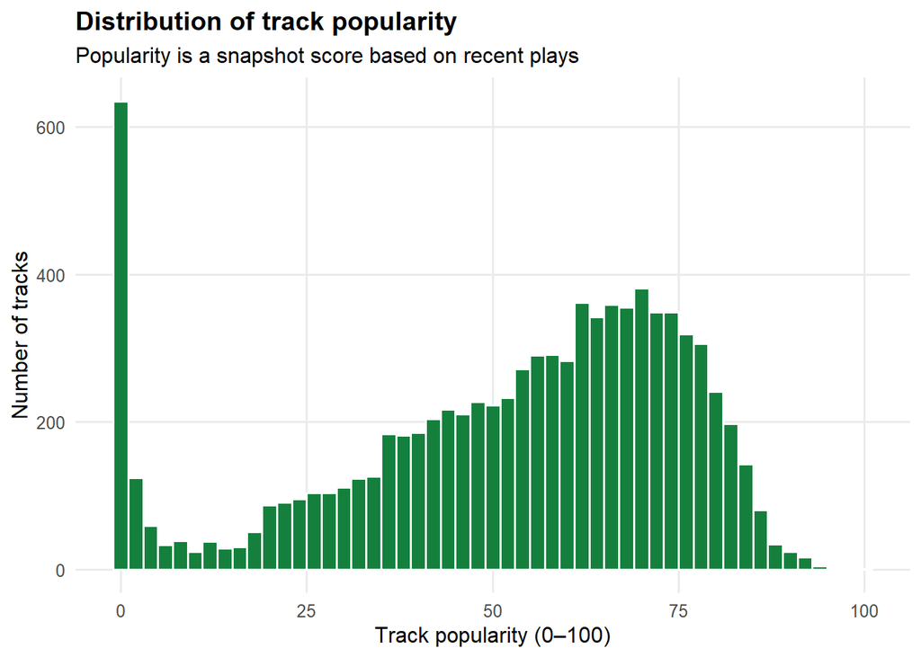

```r
ggplot(tracks, aes(track_popularity)) +
  geom_histogram(binwidth = 2, fill = col_main, colour = "white") +
  labs(x = "Track popularity (0–100)", y = "Number of tracks",
       title = "Distribution of track popularity",
       subtitle = "Popularity is a snapshot score based on recent plays")
```

### Era: how has music changed?

```r
by_year <- tracks |>
  group_by(release_year) |>
  summarise(n = n(), avg_duration = mean(duration_min),
            pct_explicit = mean(explicit), avg_popularity = mean(track_popularity),
            .groups = "drop") |>
  filter(n >= 25, release_year >= 1980)   # skip years with too few tracks
```

### Figure 2. Duration and explicit share by release year

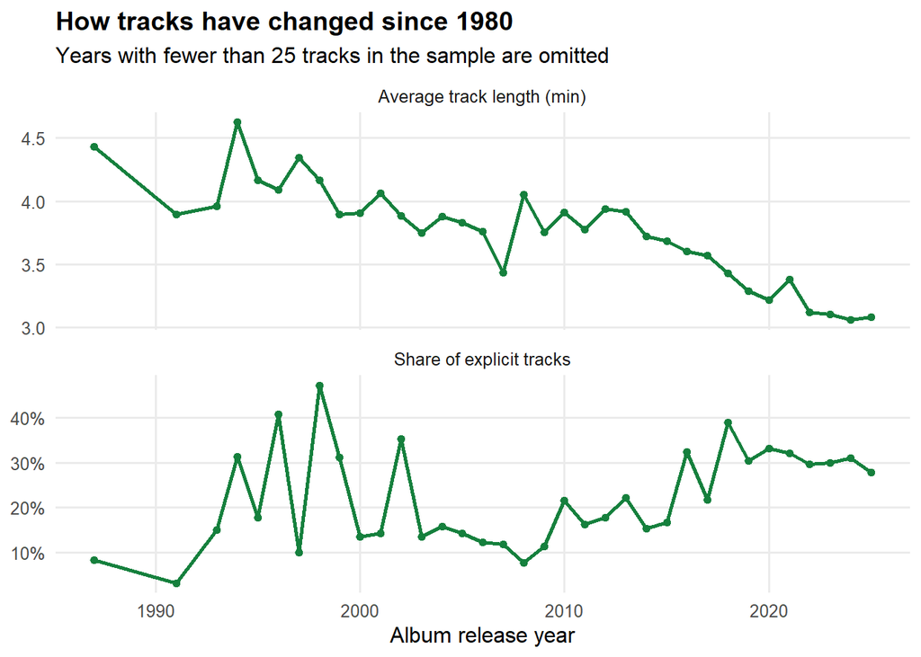

```r
by_year |>
  select(release_year, `Average track length (min)` = avg_duration,
         `Share of explicit tracks` = pct_explicit) |>
  pivot_longer(-release_year) |>
  ggplot(aes(release_year, value)) +
  geom_line(colour = col_main, linewidth = 1) +
  geom_point(colour = col_main, size = 1.5) +
  facet_wrap(~ name, ncol = 1, scales = "free_y") +
  scale_y_continuous(labels = function(x) ifelse(x <= 1, percent(x, accuracy = 1), number(x, accuracy = 0.1))) +
  labs(x = "Album release year", y = NULL,
       title = "How tracks have changed since 1980",
       subtitle = "Years with fewer than 25 tracks in the sample are omitted")
```

### Table 3. Era summary by decade

```r
tracks |>
  group_by(Decade = decade) |>
  summarise(Tracks = n(),
            `Avg popularity` = mean(track_popularity),
            `Avg length (min)` = mean(duration_min),
            `% explicit` = 100 * mean(explicit),
            `% singles` = 100 * mean(album_type == "single"),
            .groups = "drop") |>
  filter(Tracks >= 25) |>
  mutate(across(starts_with("Avg"), ~ round(.x, 2)),
         across(starts_with("%"), ~ round(.x, 1)),
         Tracks = comma(Tracks)) |>
  kable(align = c("l", rep("r", 5)))
```

| Decade | Tracks | Avg popularity | Avg length (min) | % explicit | % singles |
| --- | --- | --- | --- | --- | --- |
| 1960s | 50 | 52.66 | 2.97 | 0.0 | 2.0 |
| 1970s | 80 | 63.70 | 4.66 | 2.5 | 0.0 |
| 1980s | 100 | 59.68 | 4.28 | 4.0 | 0.0 |
| 1990s | 406 | 51.05 | 4.11 | 21.2 | 2.5 |
| 2000s | 937 | 53.09 | 3.81 | 14.4 | 3.5 |
| 2010s | 3,827 | 51.96 | 3.64 | 24.5 | 16.3 |
| 2020s | 3,369 | 51.98 | 3.15 | 30.4 | 46.9 |

### Genre: which genres are most popular?

```r
genre_long <- tracks |>
  filter(!is.na(genres)) |>
  separate_longer_delim(genres, ", ") |>
  rename(genre = genres)

genre_summary <- genre_long |>
  group_by(genre) |>
  summarise(Tracks = n(), Artists = n_distinct(artist_name),
            `Avg popularity` = mean(track_popularity),
            `% explicit` = 100 * mean(explicit),
            `Avg length (min)` = mean(duration_min),
            .groups = "drop") |>
  filter(Tracks >= 30, Artists >= 5)   # avoid genres driven by one or two artists
```

### Figure 3. Top 12 genres by average track popularity

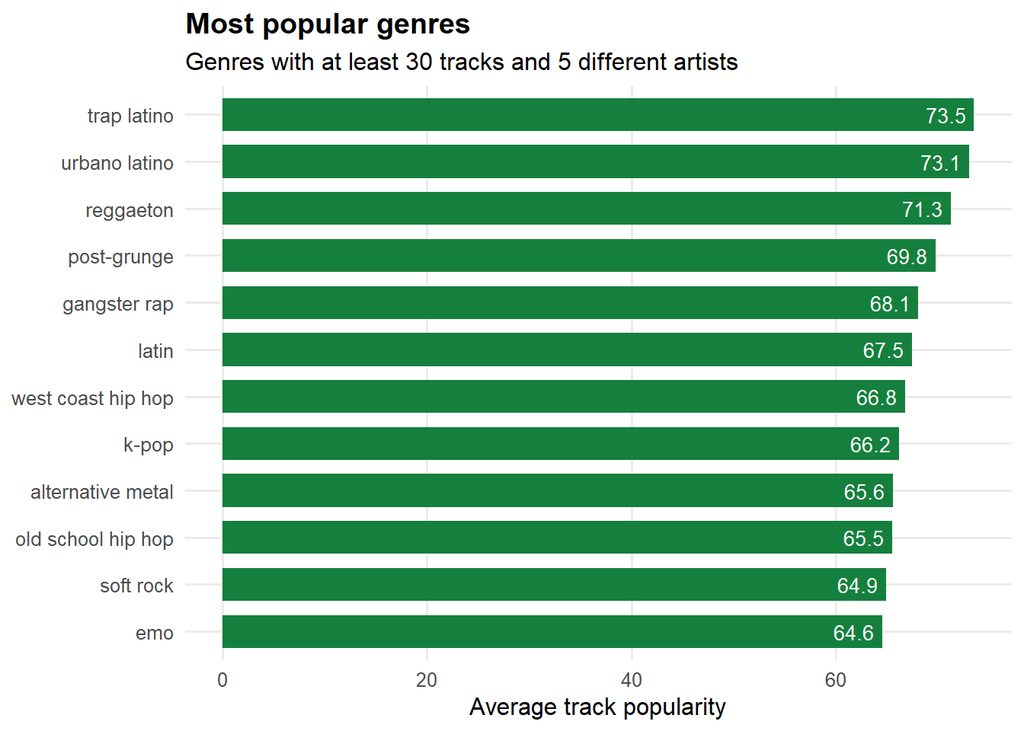

```r
genre_summary |>
  slice_max(`Avg popularity`, n = 12) |>
  ggplot(aes(`Avg popularity`, fct_reorder(genre, `Avg popularity`))) +
  geom_col(fill = col_main, width = 0.7) +
  geom_text(aes(label = round(`Avg popularity`, 1)), hjust = 1.2, colour = "white", size = 3.5) +
  labs(x = "Average track popularity", y = NULL,
       title = "Most popular genres",
       subtitle = "Genres with at least 30 tracks and 5 different artists")
```

### Table 4. Genre profile: top 10 genres by average popularity

```r
genre_summary |>
  slice_max(`Avg popularity`, n = 10) |>
  mutate(across(c(`Avg popularity`, `% explicit`, `Avg length (min)`), ~ round(.x, 1)),
         Tracks = comma(Tracks)) |>
  rename(Genre = genre) |>
  kable(align = c("l", rep("r", 5)))
```

| Genre | Tracks | Artists | Avg popularity | % explicit | Avg length (min) |
| --- | --- | --- | --- | --- | --- |
| trap latino | 64 | 7 | 73.5 | 78.1 | 3.7 |
| urbano latino | 74 | 9 | 73.1 | 74.3 | 3.6 |
| reggaeton | 86 | 16 | 71.3 | 66.3 | 3.6 |
| post-grunge | 36 | 17 | 69.8 | 8.3 | 4.1 |
| gangster rap | 33 | 12 | 68.1 | 100.0 | 4.4 |
| latin | 98 | 15 | 67.5 | 55.1 | 3.5 |
| west coast hip hop | 40 | 12 | 66.8 | 90.0 | 3.9 |
| k-pop | 93 | 21 | 66.2 | 23.7 | 3.3 |
| alternative metal | 88 | 17 | 65.6 | 11.4 | 3.8 |
| old school hip hop | 63 | 26 | 65.5 | 90.5 | 4.2 |

### Figure 4. Popularity by broad genre family

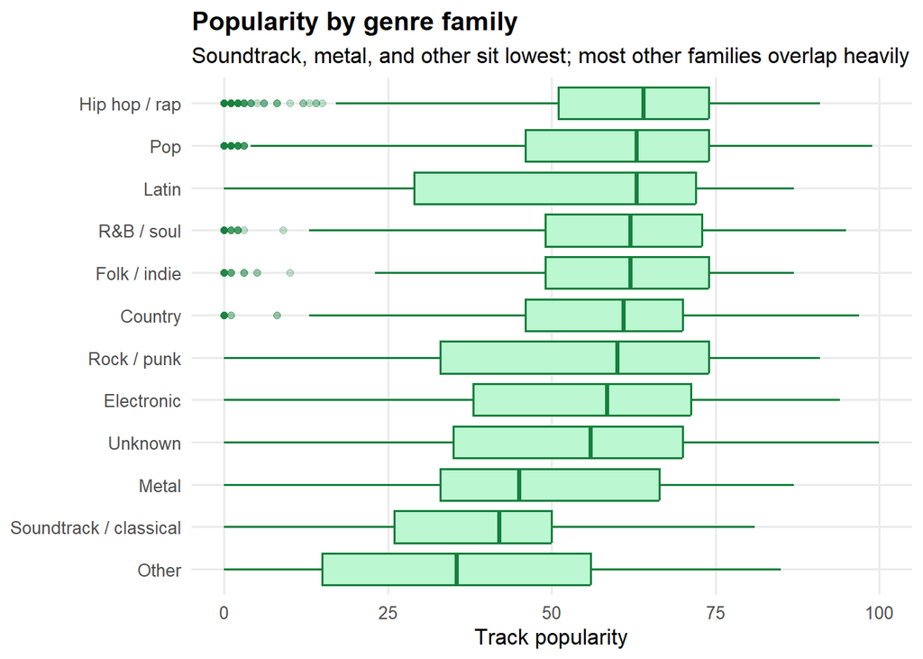

```r
ggplot(tracks, aes(track_popularity, fct_reorder(genre_family, track_popularity, .fun = median))) +
  geom_boxplot(fill = "#BBF7D0", colour = col_main, outlier.alpha = 0.25) +
  labs(x = "Track popularity", y = NULL,
       title = "Popularity by genre family",
       subtitle = "Soundtrack, metal, and other sit lowest; most other families overlap heavily")
```

### Figure 5. Artist popularity vs. track popularity

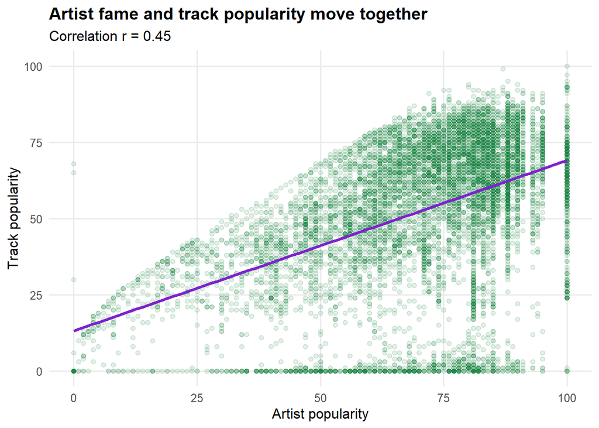

```r
r_artist <- cor(tracks$artist_popularity, tracks$track_popularity)

ggplot(tracks, aes(artist_popularity, track_popularity)) +
  geom_point(alpha = 0.12, colour = col_main) +
  geom_smooth(method = "lm", se = FALSE, colour = col_accent, linewidth = 1.2) +
  labs(x = "Artist popularity", y = "Track popularity",
       title = "Artist fame and track popularity move together",
       subtitle = paste0("Correlation r = ", round(r_artist, 2)))
```

### Table 5. Hidden gems: popular tracks from small artists

A scouting use case for a label: tracks with popularity of 70 or more from artists with under 100,000 followers.

```r
tracks |>
  filter(track_popularity >= 70, artist_followers < 1e5) |>
  arrange(desc(track_popularity), artist_followers) |>
  slice_head(n = 10) |>
  transmute(Artist = artist_name, Track = track_name,
            Popularity = track_popularity,
            Followers = comma(artist_followers),
            Year = release_year) |>
  kable(align = c("l", "l", "r", "r", "r"))
```

| Artist | Track | Popularity | Followers | Year |
| --- | --- | --- | --- | --- |
| cassö | Prada | 80 | 91,131 | 2023 |
| Majestic | Rasputin | 78 | 99,150 | 2021 |
| The American Dawn | Her | 77 | 68,931 | 2024 |
| Reed Wonder | The Machine | 74 | 99,854 | 2023 |
| Max Dean | Can’t Decide | 73 | 45,843 | 2025 |
| Myles Lloyd | Crazy | 72 | 38,082 | 2025 |
| John + Jane Q. Public | Watermelon | 72 | 57,270 | 2022 |
| zandros | obsessed | 72 | 77,490 | 2022 |
| I’ll Take You There Choir | Like a Prayer - Choir Version From “Deadpool & Wolverine” | 71 | 8,928 | 2024 |
| ZULAN | Forever | 70 | 33,160 | 2025 |

## 4. Model: what predicts popularity?

To be honest about generalization, the data is split **by artist** (80% of artists for training, 20% held out for testing). A random split would put the same artist, with the same artist-level numbers, in both sets and make the model look better than it is.

```r
# Group split by artist
artists      <- unique(tracks$artist_name)
test_artists <- sample(artists, size = round(0.2 * length(artists)))

model_data <- tracks |>
  transmute(track_popularity,
            release_year, genre_family, explicit = factor(explicit),
            duration_min, album_type, album_total_tracks, track_number,
            artist_popularity, log_followers = log10(artist_followers + 1),
            artist_name) |>
  drop_na()

train <- model_data |> filter(!artist_name %in% test_artists) |> select(-artist_name)
test  <- model_data |> filter( artist_name %in% test_artists) |> select(-artist_name)

track_only_vars <- setdiff(names(train), c("artist_popularity", "log_followers"))

fit_rf <- function(vars) {
  ranger(track_popularity ~ ., data = train[, c("track_popularity", vars)],
         num.trees = 300, importance = "permutation", seed = 607)
}
rf_full  <- fit_rf(setdiff(names(train), "track_popularity"))
rf_track <- fit_rf(setdiff(track_only_vars, "track_popularity"))
lm_full  <- lm(track_popularity ~ ., data = train)

metrics <- function(truth, pred) {
  tibble(RMSE = sqrt(mean((truth - pred)^2)),
         MAE  = mean(abs(truth - pred)),
         `R²` = 1 - sum((truth - pred)^2) / sum((truth - mean(truth))^2))
}

results <- bind_rows(
  `Baseline: predict the training mean` = metrics(test$track_popularity, mean(train$track_popularity)),
  `Linear regression (all variables)`   = metrics(test$track_popularity, predict(lm_full, test)),
  `Random forest — track, genre, era only` = metrics(test$track_popularity, predict(rf_track, test)$predictions),
  `Random forest — plus artist popularity & followers` = metrics(test$track_popularity, predict(rf_full, test)$predictions),
  .id = "Model"
)
```

### Table 6. Test-set performance (unseen artists)

```r
results |>
  mutate(across(where(is.numeric), ~ round(.x, 3))) |>
  kable(align = c("l", "r", "r", "r"))
```

| Model | RMSE | MAE | R² |
| --- | --- | --- | --- |
| Baseline: predict the training mean | 24.183 | 19.835 | -0.003 |
| Linear regression (all variables) | 20.440 | 15.279 | 0.283 |
| Random forest — track, genre, era only | 22.404 | 17.683 | 0.139 |
| Random forest — plus artist popularity & followers | 20.576 | 15.228 | 0.274 |

```r
r2_full  <- results$`R²`[results$Model == "Random forest — plus artist popularity & followers"]
r2_track <- results$`R²`[results$Model == "Random forest — track, genre, era only"]
```

### Figure 6. What matters most? Variable importance with and without the artist

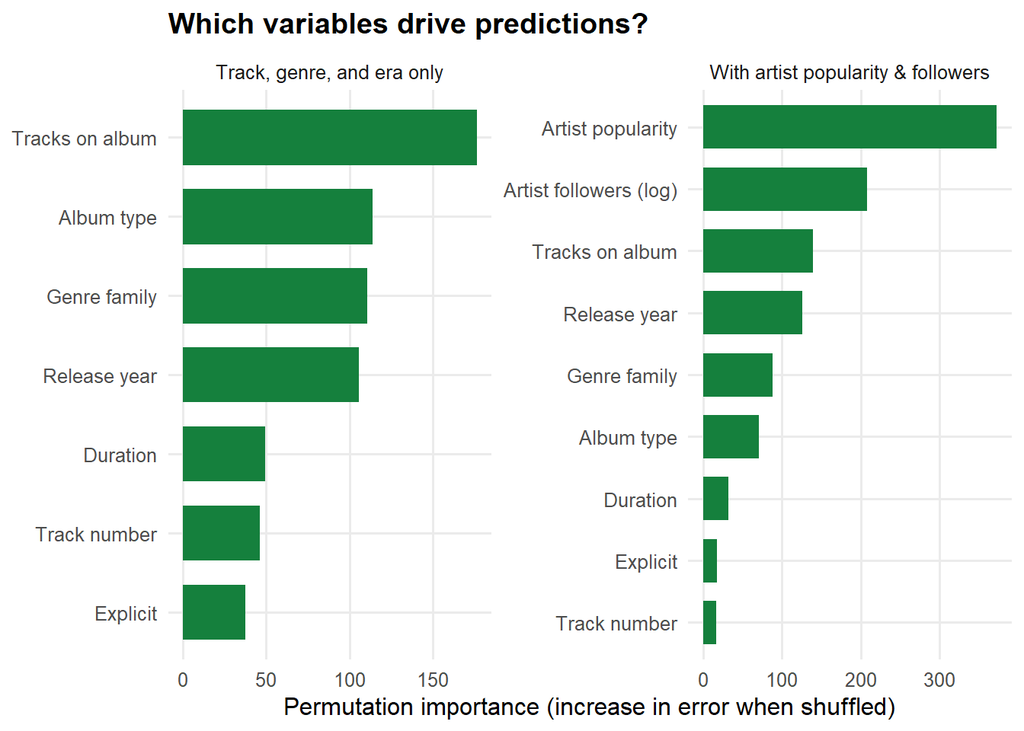

```r
imp <- bind_rows(
  enframe(rf_full$variable.importance,  "variable", "importance") |>
    mutate(model = "With artist popularity & followers"),
  enframe(rf_track$variable.importance, "variable", "importance") |>
    mutate(model = "Track, genre, and era only")
) |>
  mutate(variable = recode(variable,
    artist_popularity = "Artist popularity", log_followers = "Artist followers (log)",
    release_year = "Release year", genre_family = "Genre family",
    duration_min = "Duration", album_type = "Album type",
    album_total_tracks = "Tracks on album", track_number = "Track number",
    explicit = "Explicit"))

# Sort bars separately inside each panel
imp <- imp |> mutate(var_panel = fct_reorder(paste(variable, model, sep = "___"), importance))

ggplot(imp, aes(importance, var_panel)) +
  geom_col(fill = col_main, width = 0.7) +
  scale_y_discrete(labels = function(x) sub("___.*$", "", x)) +
  facet_wrap(~ model, scales = "free") +
  labs(x = "Permutation importance (increase in error when shuffled)", y = NULL,
       title = "Which variables drive predictions?")
```